ELMALEH Tom  
KARUNATHASAN Nilany  
SAMBATH Sïndoumady  
DIA3  
[Our Github](https://github.com/nilanyK/ESILV---Python-For-Data-Analysis---Project-2023/blob/main/README.md)

#### FINAL PROJECT - PYTHON FOR DATA ANALYSIS

# Online Shoppers Purchasing Intention

Among the 3 datasets that were assigned to us, "Online Shopper Purchasing Intention dataset" is the one that we have chose to study for the final project of this module. The main purpose of this dataset is to predict the purchasing intention of a visitor for a particular online store.

## SUMMARY

1. Importing libraries  
2. Data loading and cleaning  
3. Data visualization  
4. Data pre-processing  
5. Machine Learning & modeling  
6. API

## 1. Importing libraries

We are first going to import the libraries that will be useful for our analysis.

```python
import pandas as pd
import numpy as np


import matplotlib.pyplot as plt
import seaborn as sns
import squarify
import plotly.graph_objects as go



import sklearn
import warnings
warnings.filterwarnings('ignore')
```

## 2. Data loading and cleaning

### Dataset exploration

```python
pd.set_option('display.max_columns', None) #to display all columns
df_dataset=pd.read_csv('online_shoppers_intention.csv')
df_dataset
```

|  | Administrative | Administrative_Duration | Informational | Informational_Duration | ProductRelated | ProductRelated_Duration | BounceRates | ExitRates | PageValues | SpecialDay | Month | OperatingSystems | Browser | Region | TrafficType | VisitorType | Weekend | Revenue |
| --- | --- | --- | --- | --- | --- | --- | --- | --- | --- | --- | --- | --- | --- | --- | --- | --- | --- | --- |
| 0 | 0 | 0.0 | 0 | 0.0 | 1 | 0.000000 | 0.200000 | 0.200000 | 0.000000 | 0.0 | Feb | 1 | 1 | 1 | 1 | Returning_Visitor | False | False |
| 1 | 0 | 0.0 | 0 | 0.0 | 2 | 64.000000 | 0.000000 | 0.100000 | 0.000000 | 0.0 | Feb | 2 | 2 | 1 | 2 | Returning_Visitor | False | False |
| 2 | 0 | 0.0 | 0 | 0.0 | 1 | 0.000000 | 0.200000 | 0.200000 | 0.000000 | 0.0 | Feb | 4 | 1 | 9 | 3 | Returning_Visitor | False | False |
| 3 | 0 | 0.0 | 0 | 0.0 | 2 | 2.666667 | 0.050000 | 0.140000 | 0.000000 | 0.0 | Feb | 3 | 2 | 2 | 4 | Returning_Visitor | False | False |
| 4 | 0 | 0.0 | 0 | 0.0 | 10 | 627.500000 | 0.020000 | 0.050000 | 0.000000 | 0.0 | Feb | 3 | 3 | 1 | 4 | Returning_Visitor | True | False |
| ... | ... | ... | ... | ... | ... | ... | ... | ... | ... | ... | ... | ... | ... | ... | ... | ... | ... | ... |
| 12325 | 3 | 145.0 | 0 | 0.0 | 53 | 1783.791667 | 0.007143 | 0.029031 | 12.241717 | 0.0 | Dec | 4 | 6 | 1 | 1 | Returning_Visitor | True | False |
| 12326 | 0 | 0.0 | 0 | 0.0 | 5 | 465.750000 | 0.000000 | 0.021333 | 0.000000 | 0.0 | Nov | 3 | 2 | 1 | 8 | Returning_Visitor | True | False |
| 12327 | 0 | 0.0 | 0 | 0.0 | 6 | 184.250000 | 0.083333 | 0.086667 | 0.000000 | 0.0 | Nov | 3 | 2 | 1 | 13 | Returning_Visitor | True | False |
| 12328 | 4 | 75.0 | 0 | 0.0 | 15 | 346.000000 | 0.000000 | 0.021053 | 0.000000 | 0.0 | Nov | 2 | 2 | 3 | 11 | Returning_Visitor | False | False |
| 12329 | 0 | 0.0 | 0 | 0.0 | 3 | 21.250000 | 0.000000 | 0.066667 | 0.000000 | 0.0 | Nov | 3 | 2 | 1 | 2 | New_Visitor | True | False |

12330 rows × 18 columns

```python
df_dataset.shape
```

```
(12330, 18)
```

```python
df_dataset.info()
```

```
<class 'pandas.core.frame.DataFrame'>
RangeIndex: 12330 entries, 0 to 12329
Data columns (total 18 columns):
 #   Column                   Non-Null Count  Dtype
---  ------                   --------------  -----
 0   Administrative           12330 non-null  int64
 1   Administrative_Duration  12330 non-null  float64
 2   Informational            12330 non-null  int64
 3   Informational_Duration   12330 non-null  float64
 4   ProductRelated           12330 non-null  int64
 5   ProductRelated_Duration  12330 non-null  float64
 6   BounceRates              12330 non-null  float64
 7   ExitRates                12330 non-null  float64
 8   PageValues               12330 non-null  float64
 9   SpecialDay               12330 non-null  float64
 10  Month                    12330 non-null  object
 11  OperatingSystems         12330 non-null  int64
 12  Browser                  12330 non-null  int64
 13  Region                   12330 non-null  int64
 14  TrafficType              12330 non-null  int64
 15  VisitorType              12330 non-null  object
 16  Weekend                  12330 non-null  bool
 17  Revenue                  12330 non-null  bool
dtypes: bool(2), float64(7), int64(7), object(2)
memory usage: 1.5+ MB
```

The dataset consists of 10 numerical and 8 categorical attributes. The 'Revenue' attribute can be used as the class label. Of the 12,330 sessions in the dataset, 84.5% (10,422) were negative class samples that did not end with shopping, and the rest (1908) were positive class samples ending with shopping.

Columns descriptions :

- **Administrative** : Number of administrative type pages visited by the user.
- **Administrative_Duration** : Total time spent in this category of page.
- **Informational** : Number of iformational type pages visited by the user.
- **Informational_Duration** : Total time spent in this category of page.
- **ProductRelated** : Number of product related type pages visited by the user.
- **ProductRelated_Duration** : Total time spent in this category of page.
- **BounceRates** : Percentage of visitors who enter the site from that page and then leave ("bounce") without triggering any other requests to the analytics server during that session.
- **ExitRates:** Percentage of pageviews on the website that end at that specific page.
- **PageValues** : The average value of the page averaged over the value of the target page and/or the completion of an eCommerce transaction.
- **SpecialDay** : Indicates the closeness of the site visiting time to a specific special day (e.g. Mother’s Day, Valentine's Day) in which the sessions are more likely to be finalized with transaction.
- **Month** : The month that the pageview occurred
- **OperatingSystems** : An integer value representing the operating system that the user was on when viewing the page.
- **Browser** : An integer value representing the browser that the user was using to view the page.
- **Region** : An integer value representing which region the user is located in.
- **TrafficType** : An integer value representing what type of traffic the user is categorized into.
- **VisitorType** : A string representing whether a visitor is new, returning or other.
- **Weekend** : A boolean representing whether the session is on a weekend.
- **Revenue** : A boolean representing whether or not the user completed the purchase.

### Data cleaning

**• Checking for NA values**

```python
df_dataset.isna().sum()
```

```
Administrative             0
Administrative_Duration    0
Informational              0
Informational_Duration     0
ProductRelated             0
ProductRelated_Duration    0
BounceRates                0
ExitRates                  0
PageValues                 0
SpecialDay                 0
Month                      0
OperatingSystems           0
Browser                    0
Region                     0
TrafficType                0
VisitorType                0
Weekend                    0
Revenue                    0
dtype: int64
```

As we can see, the dataset has no NA values per column.

We are going to check the number of null values per column.

```python
# Count number of zeros in all columns of the Dataframe
for column_name in df_dataset.columns:
    column = df_dataset[column_name]
    # Get the count of Zeros in column
    count = (column == 0).sum()
    print('Count of zeros in column ', column_name, ' is : ', count)
```

```
Count of zeros in column  Administrative  is :  5768
Count of zeros in column  Administrative_Duration  is :  5903
Count of zeros in column  Informational  is :  9699
Count of zeros in column  Informational_Duration  is :  9925
Count of zeros in column  ProductRelated  is :  38
Count of zeros in column  ProductRelated_Duration  is :  755
Count of zeros in column  BounceRates  is :  5518
Count of zeros in column  ExitRates  is :  76
Count of zeros in column  PageValues  is :  9600
Count of zeros in column  SpecialDay  is :  11079
Count of zeros in column  Month  is :  0
Count of zeros in column  OperatingSystems  is :  0
Count of zeros in column  Browser  is :  0
Count of zeros in column  Region  is :  0
Count of zeros in column  TrafficType  is :  0
Count of zeros in column  VisitorType  is :  0
Count of zeros in column  Weekend  is :  9462
Count of zeros in column  Revenue  is :  10422
```

```python
df_clean = df_dataset.drop(columns=df_dataset.columns[:3], axis=1)
df_clean
```

|  | Informational_Duration | ProductRelated | ProductRelated_Duration | BounceRates | ExitRates | PageValues | SpecialDay | Month | OperatingSystems | Browser | Region | TrafficType | VisitorType | Weekend | Revenue |
| --- | --- | --- | --- | --- | --- | --- | --- | --- | --- | --- | --- | --- | --- | --- | --- |
| 0 | 0.0 | 1 | 0.000000 | 0.200000 | 0.200000 | 0.000000 | 0.0 | Feb | 1 | 1 | 1 | 1 | Returning_Visitor | False | False |
| 1 | 0.0 | 2 | 64.000000 | 0.000000 | 0.100000 | 0.000000 | 0.0 | Feb | 2 | 2 | 1 | 2 | Returning_Visitor | False | False |
| 2 | 0.0 | 1 | 0.000000 | 0.200000 | 0.200000 | 0.000000 | 0.0 | Feb | 4 | 1 | 9 | 3 | Returning_Visitor | False | False |
| 3 | 0.0 | 2 | 2.666667 | 0.050000 | 0.140000 | 0.000000 | 0.0 | Feb | 3 | 2 | 2 | 4 | Returning_Visitor | False | False |
| 4 | 0.0 | 10 | 627.500000 | 0.020000 | 0.050000 | 0.000000 | 0.0 | Feb | 3 | 3 | 1 | 4 | Returning_Visitor | True | False |
| ... | ... | ... | ... | ... | ... | ... | ... | ... | ... | ... | ... | ... | ... | ... | ... |
| 12325 | 0.0 | 53 | 1783.791667 | 0.007143 | 0.029031 | 12.241717 | 0.0 | Dec | 4 | 6 | 1 | 1 | Returning_Visitor | True | False |
| 12326 | 0.0 | 5 | 465.750000 | 0.000000 | 0.021333 | 0.000000 | 0.0 | Nov | 3 | 2 | 1 | 8 | Returning_Visitor | True | False |
| 12327 | 0.0 | 6 | 184.250000 | 0.083333 | 0.086667 | 0.000000 | 0.0 | Nov | 3 | 2 | 1 | 13 | Returning_Visitor | True | False |
| 12328 | 0.0 | 15 | 346.000000 | 0.000000 | 0.021053 | 0.000000 | 0.0 | Nov | 2 | 2 | 3 | 11 | Returning_Visitor | False | False |
| 12329 | 0.0 | 3 | 21.250000 | 0.000000 | 0.066667 | 0.000000 | 0.0 | Nov | 3 | 2 | 1 | 2 | New_Visitor | True | False |

12330 rows × 15 columns

**• Checking for duplicates**

We are now going to check if the dataset contains duplicates and remove them in that case.

```python
df_clean=df_clean.drop_duplicates(keep='first')
df_clean.shape
```

```
(12205, 15)
```

### Exporting the cleaned dataset

```python
df_clean.to_csv(r'online_shoppers_intention_clean.csv',index = False)
```

```python
df=pd.read_csv('online_shoppers_intention_clean.csv')
df
```

|  | Informational_Duration | ProductRelated | ProductRelated_Duration | BounceRates | ExitRates | PageValues | SpecialDay | Month | OperatingSystems | Browser | Region | TrafficType | VisitorType | Weekend | Revenue |
| --- | --- | --- | --- | --- | --- | --- | --- | --- | --- | --- | --- | --- | --- | --- | --- |
| 0 | 0.0 | 1 | 0.000000 | 0.200000 | 0.200000 | 0.000000 | 0.0 | Feb | 1 | 1 | 1 | 1 | Returning_Visitor | False | False |
| 1 | 0.0 | 2 | 64.000000 | 0.000000 | 0.100000 | 0.000000 | 0.0 | Feb | 2 | 2 | 1 | 2 | Returning_Visitor | False | False |
| 2 | 0.0 | 1 | 0.000000 | 0.200000 | 0.200000 | 0.000000 | 0.0 | Feb | 4 | 1 | 9 | 3 | Returning_Visitor | False | False |
| 3 | 0.0 | 2 | 2.666667 | 0.050000 | 0.140000 | 0.000000 | 0.0 | Feb | 3 | 2 | 2 | 4 | Returning_Visitor | False | False |
| 4 | 0.0 | 10 | 627.500000 | 0.020000 | 0.050000 | 0.000000 | 0.0 | Feb | 3 | 3 | 1 | 4 | Returning_Visitor | True | False |
| ... | ... | ... | ... | ... | ... | ... | ... | ... | ... | ... | ... | ... | ... | ... | ... |
| 12200 | 0.0 | 53 | 1783.791667 | 0.007143 | 0.029031 | 12.241717 | 0.0 | Dec | 4 | 6 | 1 | 1 | Returning_Visitor | True | False |
| 12201 | 0.0 | 5 | 465.750000 | 0.000000 | 0.021333 | 0.000000 | 0.0 | Nov | 3 | 2 | 1 | 8 | Returning_Visitor | True | False |
| 12202 | 0.0 | 6 | 184.250000 | 0.083333 | 0.086667 | 0.000000 | 0.0 | Nov | 3 | 2 | 1 | 13 | Returning_Visitor | True | False |
| 12203 | 0.0 | 15 | 346.000000 | 0.000000 | 0.021053 | 0.000000 | 0.0 | Nov | 2 | 2 | 3 | 11 | Returning_Visitor | False | False |
| 12204 | 0.0 | 3 | 21.250000 | 0.000000 | 0.066667 | 0.000000 | 0.0 | Nov | 3 | 2 | 1 | 2 | New_Visitor | True | False |

12205 rows × 15 columns

## 3. Data visualization

### Univariate Analysis

**• Visitor Type**

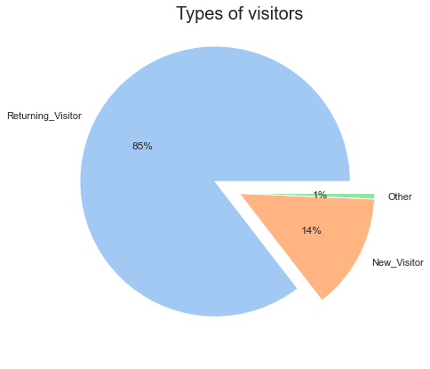

```python
p=df['VisitorType'].value_counts()
keys=['Returning_Visitor','New_Visitor','Other']

sns.set()

fig,ax = plt.subplots(figsize=(7,7))


# declaring exploding pie
explode = [0.2, 0, 0]

palette_color = sns.color_palette('pastel')

# plotting data on chart
ax.pie(p, labels=keys, colors=palette_color,
        explode=explode, autopct='%.0f%%')
plt.title("Types of visitors",fontsize = 20)
# displaying chart
plt.show()
```

As we can see, 85% of the visitors are people who have already been on the page.

**• Revenue (transactions)**

[figure not shown]

```python
fig,ax = plt.subplots(figsize=(10,7))
sns.set()
sns.countplot(x ='Revenue', data = df, palette = "Set2")
plt.title('Transactions completed vs uncompleted', fontsize= 20)
plt.ylabel('Number of transactions', fontsize=12)
plt.ylim(0,13000)
plt.text(x=-.175, y=11000 ,s='10,422', fontsize=15)
plt.text(x=.875, y=2500, s='1908', fontsize=15)
plt.show()
```

As we can see, only 1908 have been completed.

**• Weekend**

```python
!pip install squarify
```

[figure not shown]

```python
p = df.groupby('Weekend').size().reset_index(name='counts')
labels = p.apply(lambda x: str(x[0]) + "\n (" + str(x[1]) + ")", axis=1)
sizes = p['counts'].values.tolist()
colors = [plt.cm.Spectral(i/float(len(labels))) for i in range(len(labels))]

plt.figure(figsize=(12,5), dpi= 80)
squarify.plot(sizes=sizes, label=labels, color=colors, alpha=.8)


plt.title('Sessions on weekend',fontsize=20)
plt.axis('off')
plt.show()
```

From the above distribution we can see that contrary to what we could think, most of the sessions are from weekdays and not weekends.

**• Months**

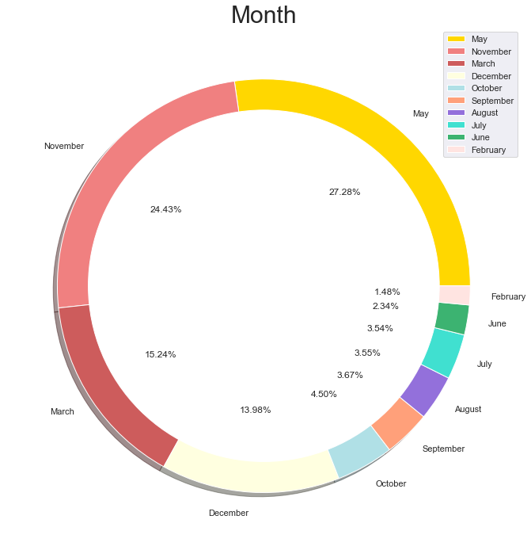

```python
p=df['Month'].value_counts()
colors = ['gold', 'lightcoral', 'indianred', 'lightyellow', 'powderblue', 'lightsalmon', 'mediumpurple', 'turquoise', 'mediumseagreen', 'mistyrose', 'azure', 'peachpuff']
labels = "May", "November", "March", "December", "October", "September", "August", "July", "June", "February"
explode = [0, 0, 0, 0, 0, 0, 0, 0, 0, 0]

circle = plt.Circle((0, 0), 0.85, color = 'white')

plt.rcParams['figure.figsize'] = (12, 12)
plt.pie(p,colors = colors, labels = labels, explode = explode, shadow = True, autopct = '%.2f%%')
plt.title('Month', fontsize = 30)
p = plt.gcf()
p.gca().add_artist(circle)
plt.axis('off')
plt.legend()
plt.show()
```

As it's suggested by the distribution above, the months that registered the most visitors are respectively :

- May marks the transition from winter to spring and more families and individuals buy goods for the seasons, completed also by Mother's day and Memorial day
- November (Black Friday, Cyber Monday)
- March (St. Patrick's Day)
- December (Christmas, Super Sathurday, New Year's Eve)

**• Special Day**

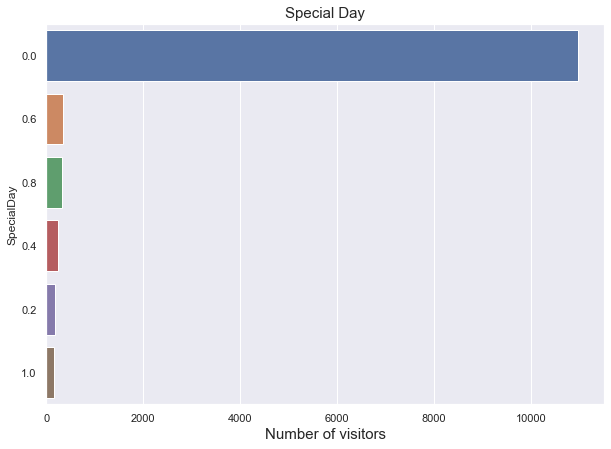

```python
sns.set()
fig,ax = plt.subplots(figsize=(10,7))
ax=sns.countplot(data=df, y="SpecialDay",order = df['SpecialDay'].value_counts().index)
plt.title('Special Day', fontsize= 15)
plt.xlabel('Number of visitors', fontsize=15)
plt.show()
```

As viewed on the dataset description, the maximum value of the feature "Special Day" is 1 on exactly the date of the special day and the minimum is 0 if the date is too far from any of the special days, other nonzero values represent the influence of the closest special day.  
Most of the transaction are done close to none of the special days, which is consitent since there are merely 4 - 5 special days but shopping is around 365 days.

**• Informational_Duration**

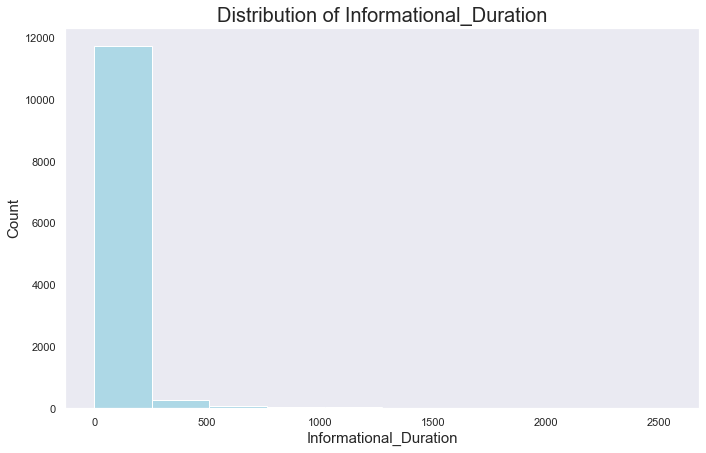

```python
plt.rcParams['figure.figsize'] = (25, 7)
plt.subplot(1, 2, 1)
plt.hist(df['Informational_Duration'], color = 'lightblue')
plt.title('Distribution of Informational_Duration', fontsize = 20)
plt.xlabel('Informational_Duration', fontsize = 15)
plt.ylabel('Count', fontsize = 15)
plt.grid()
plt.show()
```

The "Informational_Duration" variable appears a few times (near to zero) which means that the website is clear.

**• Operating Systems, Browser, Region and Traffic Type**

There are different types of Operating Systems, Browsers, Regions, and Traffic Types; although there are no details on what each category means, it might be useful to classify customers.

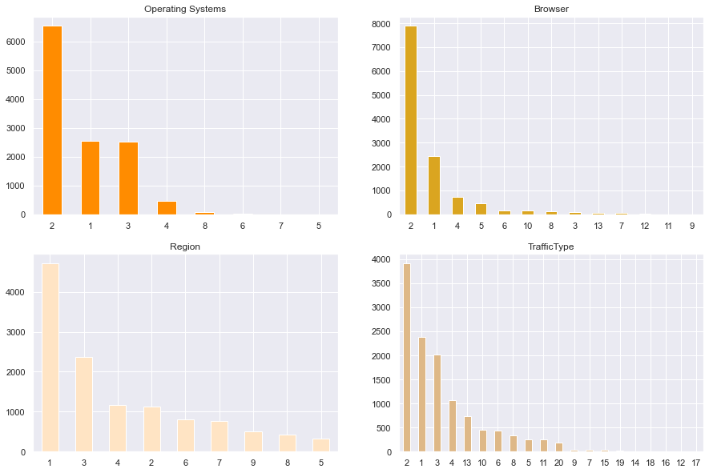

```python
fig, axarr = plt.subplots(2, 2, figsize=(15, 10))

df['OperatingSystems'].value_counts().plot.bar(
    ax=axarr[0][0],
    title='Operating Systems',
    rot=0,
    color='darkorange'
)

df['Browser'].value_counts().plot.bar(
    ax=axarr[0][1],
    title='Browser',
    rot=0,
    color='goldenrod'
)

df['Region'].value_counts().plot.bar(
    ax=axarr[1][0],
    title='Region',
    rot=0,
    color='bisque'
)

df['TrafficType'].value_counts().plot.bar(
    ax=axarr[1][1],
    title='TrafficType',
    rot=0,
    color='burlywood'
)
```

### Bivariate Analysis

**• Region and Revenue**

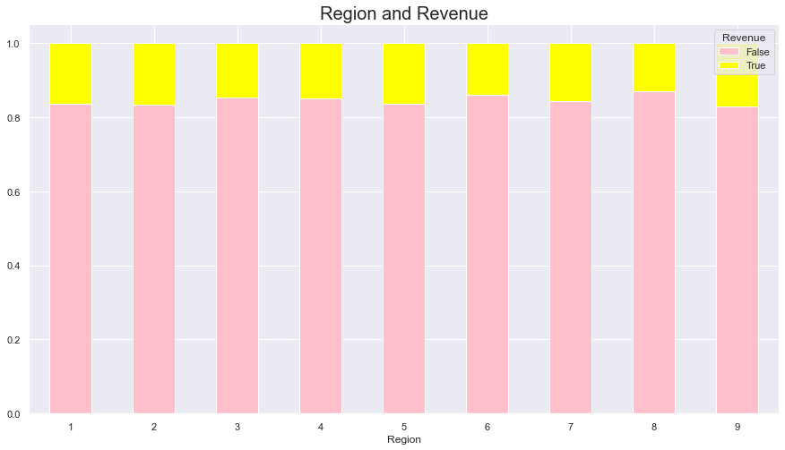

```python
df1 = pd.crosstab(df['Region'], df['Revenue'])
df1.div(df1.sum(1).astype(float), axis=0).plot(kind = 'bar', stacked = True, figsize = (15, 8), color = ['pink', 'yellow'])
plt.xticks(rotation = 0)
plt.title('Region and Revenue', fontsize = 20)
plt.show()
```

The nine regions consume more or less in the same way. Indeed, we can see that they are more likely not to make purchases.

**• Visitor Type and Weekend**

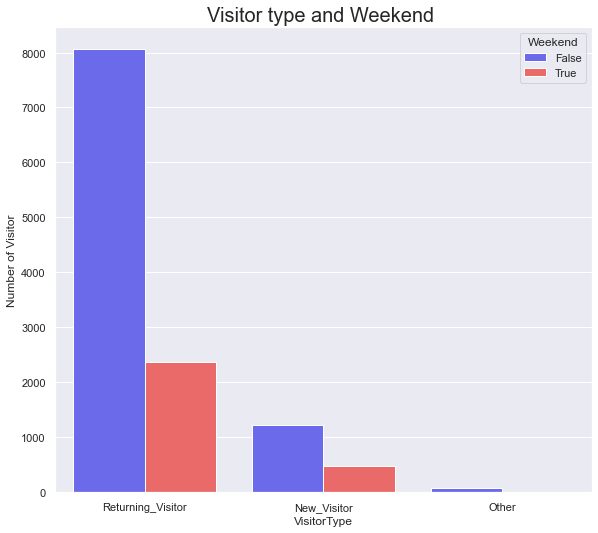

```python
plt.figure(figsize = (25,20))

ax = plt.subplot(221)
ax = sns.countplot(x="VisitorType", data=df,
              palette="seismic", hue="Weekend")
ax.set_xlabel("VisitorType", fontsize=12)
ax.set_ylabel("Number of Visitor", fontsize=12)
ax.set_title("Visitor type and Weekend ", fontsize=20)

plt.subplots_adjust(wspace = 0.6, hspace = 0.4, top = 0.9)
```

```python
table_df = pd.pivot_table(df, values=["Revenue"],
                                   index=["Weekend"],
                                   columns=["VisitorType"],
                                   aggfunc="sum",
                                   fill_value=0,
                                   margins=True)

table_df
```

| VisitorType Weekend | Revenue New_Visitor | Revenue Other | Revenue Returning_Visitor | Revenue All |
| --- | --- | --- | --- | --- |
| False | 317 | 15 | 1077 | 1409 |
| True | 105 | 1 | 393 | 499 |
| All | 422 | 16 | 1470 | 1908 |

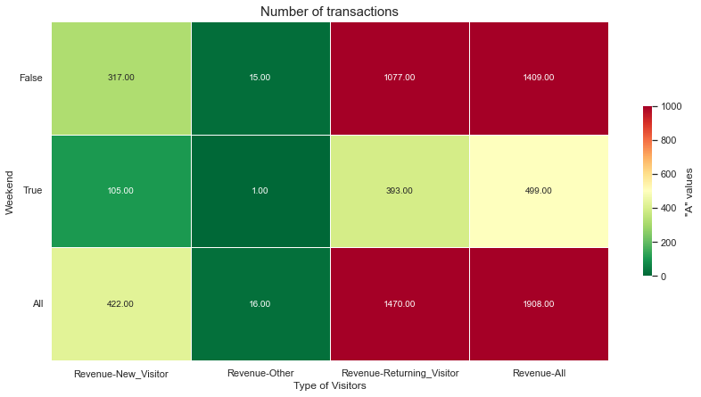

```python
fig, ax = plt.subplots(figsize=(14,7))
ax = sns.heatmap(table_df, cmap='RdYlGn_r',
                 robust=True, fmt='.2f',
                 annot=True, linewidths=.6,
                 annot_kws={'size':10},
                 cbar_kws={'shrink':.5,
                           'label':'"A" values'},
                vmin=0, vmax =1000)

ax.set_yticklabels(ax.get_yticklabels())
plt.xticks(rotation=0)
plt.yticks(rotation=0)
plt.title('Number of transactions', fontsize=15)
plt.xlabel('Type of Visitors')
plt.ylabel('Weekend')
plt.show()
```

"Returning Visitors" are those who visit and complete the most purchase on the website, but their visits are more frequent on weekdays.

**• Product_Related vs Weekend**

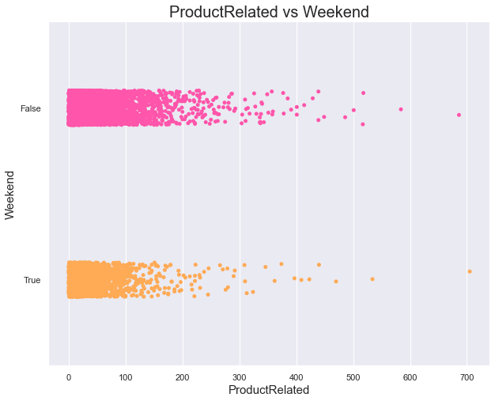

```python
plt.rcParams['figure.figsize'] = (10, 8)

sns.stripplot(df['ProductRelated'], df['Weekend'], palette = 'spring', orient = 'h')
plt.title('ProductRelated vs Weekend', fontsize = 20)
plt.xlabel('ProductRelated', fontsize = 15)
plt.ylabel('Weekend', fontsize = 15)
plt.show()
```

As shown by the above distribution, product pages aren't specially more visited than other pages during weekend.

**• ProductRelated_Duration by Revenue**

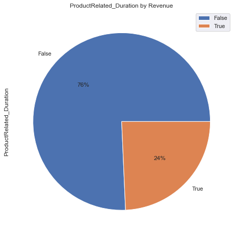

```python
df.groupby(['Revenue']).sum().plot(
    kind='pie', y='ProductRelated_Duration',title = "ProductRelated_Duration by Revenue", autopct='%1.0f%%')
```

The above pie shows that the large amount of time spent on product pages does not necessarily imply the purchase.

**• Special Day vs Revenue**

```python
!pip install palettable
```

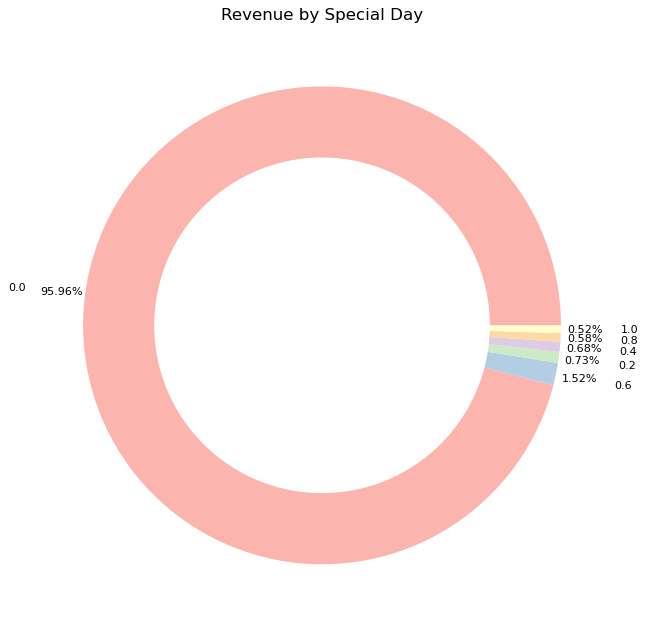

```python
dfSD_purchased = df[df["Revenue"]==True].pivot_table(index="SpecialDay",values="Revenue",
                                                        aggfunc="count").sort_values(by="Revenue",ascending=False)

labels = dfSD_purchased.index
sizes = dfSD_purchased.values
sizes = sizes.flatten()



my_circle = plt.Circle( (0,0), 0.7, color='white')

from palettable.colorbrewer.qualitative import Pastel1_7

fig, ax = plt.subplots(figsize=(15, 8), dpi=80)
ax.pie(sizes, labels=labels, colors=Pastel1_7.hex_colors,autopct = '%.2f%%',pctdistance=1.1, labeldistance=1.25)
plt.title("Revenue by Special Day",fontsize=15)

p = plt.gcf()
p.gca().add_artist(my_circle)

# Show the graph
fig.tight_layout()
plt.show()
```

This pie chart represents the percentage of users who purchased given the closeness with a special day of th year. We can notice that the special day doesn't have any influence on whether or not the user will buy the product as 96% of the users purchased on a day which is very far from the special day.

**• Revenue vs Weekend**

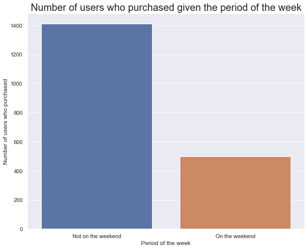

```python
dfPurchased = df[df["Revenue"]==True]
dfPurchasedweek = pd.DataFrame(dfPurchased["Weekend"].value_counts())
dfPurchasedweek.index=["Not on the weekend","On the weekend"]
plt.figure(figsize = (10,8))
sns.barplot(data=dfPurchasedweek,x=list(dfPurchasedweek.index),y="Weekend")
plt.xlabel("Period of the week")
plt.ylabel("Number of users who purchased")
plt.title("Number of users who purchased given the period of the week", fontsize=20)
plt.show()
```

We can see that most of the users are purchasing on weekdays (1409) and not on weekends (499).

**• Month vs Revenue**

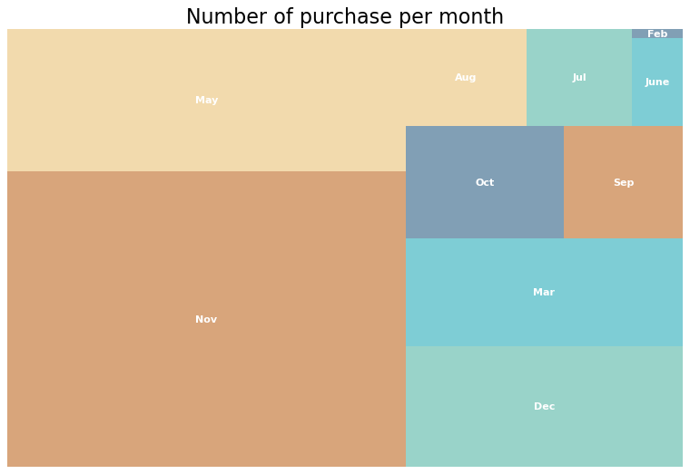

```python
dfmonth_purchased = df[df["Revenue"]==True].pivot_table(index="Month",values="Revenue",
                                                        aggfunc="sum").sort_values(by="Revenue",ascending=False)

labels = dfmonth_purchased.index
sizes = dfmonth_purchased.values
colors = ["#ce8f5a", "#efd199", "#80c8bc", "#5ec0ca", "#6287a2"]

fig, ax = plt.subplots(figsize=(12, 8), dpi=80)
squarify.plot(sizes=sizes, label=labels,color=colors,
              text_kwargs={'fontsize':10,'weight':'bold',"color":"white"}, alpha=.8)


plt.title('Number of purchase per month',fontsize=20)
plt.axis('off');
plt.show();
```

We can notice that the months on which the users purchase the most are November (Black friday before Christmas), May (Mother's Day, Father's Day) and December (Christmas).

**• Region, Product Related and Visitor Type**

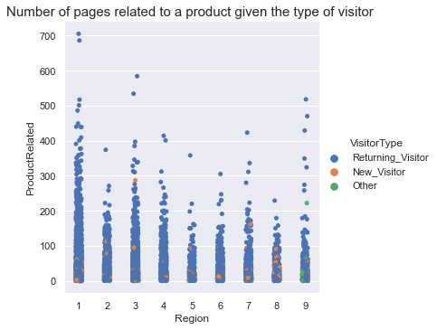

```python
sns.catplot(x="Region",y="ProductRelated",data=df,hue="VisitorType")
plt.title("Number of pages related to a product given the type of visitor ", fontsize=15)
plt.show();
```

This plot represents the number of pages consulted which are related to a product given the type of visitor. We can notice that a returning_visitor consults more pages related to a product compared to other types of visitors.

## 4. Data pre-processing

```python
from sklearn.preprocessing import OneHotEncoder,MinMaxScaler,StandardScaler,MaxAbsScaler,OrdinalEncoder
from sklearn.compose import make_column_transformer
from sklearn.utils import resample
from sklearn.model_selection import train_test_split
```

```python
# Separating features and target
X = df.drop(columns=['Revenue']) # features
y = df['Revenue'] #target
```

**• Encoding**

We will use `make_column_transformer` to transform all variables selected using OrdinalEncoder and encode categorical fetaures.

```python
transformer = make_column_transformer((OrdinalEncoder(), ['Month','Browser','Region','OperatingSystems','TrafficType','VisitorType','Weekend']),remainder='passthrough')
X = transformer.fit_transform(X)
```

**• Unbalanced dataset & Resampling strategy**

Let's first check how unbalanced our dataset is.

```
Class False: 10297
Class True : 1908
Proportion: 5.4 : 1
```

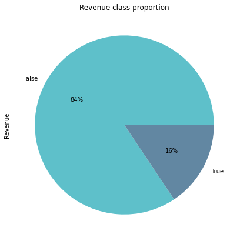

```python
Y_count = y.value_counts()
print('Class False:', Y_count[0])
print('Class True :', Y_count[1])
print('Proportion:', round(Y_count[0] / Y_count[1], 2), ': 1')
colors =["#5ec0ca", "#6287a2"]

fig,ax = plt.subplots(figsize=(10,7))

Y_count.plot(kind='pie',title='Revenue class proportion', autopct='%1.0f%%',colors=colors);
```

As we can see, our dataset is highly unbalanced. Oversampling the minority class is one method for dealing with umbalanced datasets. The most basic method involves duplicating examples from the minority class, even though these examples add no new information to the model. Instead, new examples can be created by combining existing ones. The Synthetic Minority Oversampling Technique, or SMOTE, is a type of data augmentation for the minority class.

To create a synthetic individual, the steps defined in the SMOTE algorithm are :

1. Randomly select an “initial” minority observation.
2. Identify its closest neighbors k among the minority observations (where k is a user-defined parameter).
3. Randomly choose one of the nearest neighbors k.
4. Randomly generate an α ranged as follow `0 < α < 1`
5. Create a new individual between the initial observation and the nearest selected neighbour, based on the coefficient value. For example, if `α = 0.5`, the new individual will be positioned halfway between the initial observation and the nearest selected neighbour

```python
!pip install imblearn
```

```python
from imblearn.over_sampling import SMOTE
from matplotlib.pyplot import *

smote = SMOTE(sampling_strategy='minority')
X, y = smote.fit_resample(X, y)
```

```
Class False: 10297
Class True : 10297
Proportion: 1.0 : 1
```

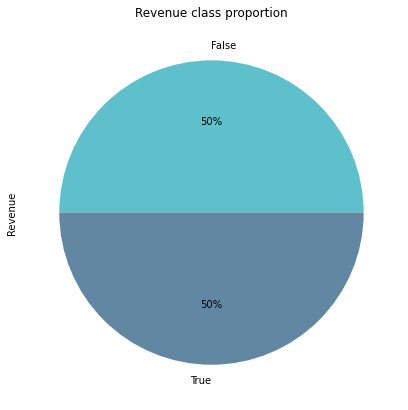

```python
Y_count = y.value_counts()
print('Class False:', Y_count[0])
print('Class True :', Y_count[1])
print('Proportion:', round(Y_count[0] / Y_count[1], 2), ': 1')
colors =["#5ec0ca", "#6287a2"]

fig,ax = plt.subplots(figsize=(10,7))

Y_count.plot(kind='pie',title='Revenue class proportion', autopct='%1.0f%%',colors=colors);
```

As shown by the above pie, now we have a balanced dataset.

**• Splitting the dataset into training and testing datasets**

```python
X_train, X_test, Y_train, Y_test = train_test_split(X,y,test_size=0.20,random_state=42)
```

**• Scaling**

```python
scaler = MaxAbsScaler()
X_train = scaler.fit_transform(X_train)
X_test = scaler.transform(X_test)
```

## 5. Machine Learning & Tuning

In order to get the best set of hyperparameters we are going to use the Grid Search method.

Grid search is a model hyperparameter optimization technique. In scikit-learn, this technique is provided in the GridSearchCV class.

When constructing this class, we must provide the list of hyperparameters to evaluate in the `param_grid` argument.

By default, the grid search will only use one thread.

By setting the `n_jobs` argument in the `GridSearchCV` constructor to -1, the process will use all cores on our machine.

The GridSearchCV process will then construct and evaluate one model for each combination of parameters. Cross validation is used to evaluate each individual model. Grid Search passes all combinations of hyperparameters one by one into a model and check the result. Finally it gives us the set of hyperparemeters which gives the best result after passing in the model.

The models on which we are going to perform this process are the following : KNN, Naive Bayes Classifier, Decision Tree, Random Forest, XGBoost, SVC, Stochastic Gradient Descent and Gradient Boosting Score.

For each model, we will stick to the following steps :

1. Import the necessary libraries
2. Define the grid parameters
3. Apply `GridSearchCV` and evaluate the result
4. Save the best model obtained in a specified variable using `best_estimator_`
5. Save the score obtained on the test set using the model we just defined earlier.
6. Plot the `confusion matrix` to evaluate the performance of the model.

**• KNN**

```python
from sklearn.neighbors import KNeighborsClassifier
from sklearn.model_selection import cross_val_score
from sklearn.model_selection import GridSearchCV
```

```python
params = {'n_neighbors' : np.arange(2,20),
          'metric':['euclidean','manhattan','minkowski','chebyshev'],
          'weights': ('uniform', 'distance'),
         }
knn_grid = GridSearchCV(KNeighborsClassifier(),param_grid=params,cv=5)

knn_grid.fit(X_train,Y_train)

print('Best Parameters : {}'.format(knn_grid.best_params_))
print('Best Accuracy Through Grid Search : {:.3f}\n'.format(knn_grid.best_score_))
```

```
Best Parameters : {'metric': 'manhattan', 'n_neighbors': 4, 'weights': 'distance'}
Best Accuracy Through Grid Search : 0.893
```

```python
model_knn = knn_grid.best_estimator_
```

```python
test_score_knn = model_knn.score(X_test,Y_test)
test_score_knn
```

```
0.9113862588006798
```

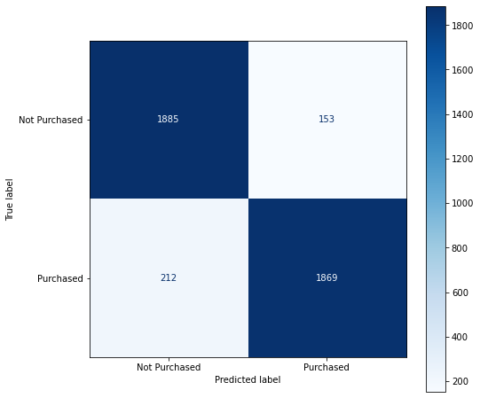

```python
from sklearn.metrics import plot_confusion_matrix

fig, ax = plt.subplots(figsize=(8, 8))
plot_confusion_matrix(model_knn, X_test, Y_test, display_labels=['Not Purchased',
 'Purchased',], cmap=plt.cm.Blues,ax=ax);
```

**• Naive Bayes Classifier**

```python
from sklearn.naive_bayes import BernoulliNB

params = {'alpha': [0.01, 0.1, 0.5, 1.0, 10.0],
          'fit_prior': [True, False],
          'class_prior': [None, [0.1,]* 2, ],
          'binarize': [None, 0.0, 8.5, 10.0]
         }

bernoulli_nb_grid = GridSearchCV(BernoulliNB(), param_grid=params, n_jobs=-1, cv=5, verbose=5)
bernoulli_nb_grid.fit(X_train,Y_train)

print('Best Parameters : {}'.format(bernoulli_nb_grid.best_params_))
print('Best Accuracy Through Grid Search : {:.3f}\n'.format(bernoulli_nb_grid.best_score_))
```

```
Fitting 5 folds for each of 80 candidates, totalling 400 fits
Best Parameters : {'alpha': 10.0, 'binarize': 0.0, 'class_prior': None, 'fit_prior': True}
Best Accuracy Through Grid Search : 0.878
```

```python
model_nb = bernoulli_nb_grid.best_estimator_
```

```python
test_score_nb = model_nb.score(X_test,Y_test)
test_score_nb
```

```
0.8832240835154164
```

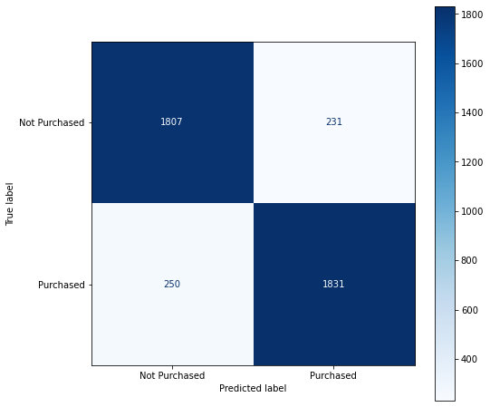

```python
from sklearn.metrics import plot_confusion_matrix
fig, ax = plt.subplots(figsize=(8, 8))
plot_confusion_matrix(model_nb, X_test, Y_test, display_labels=['Not Purchased',
 'Purchased',], cmap=plt.cm.Blues,ax=ax);
```

**• Decision Tree**

```python
from sklearn.tree import DecisionTreeClassifier

params = {"criterion": ['gini','entropy'],
        "max_depth": range(1,10),
        "min_samples_split": range(1,10),
        "min_samples_leaf": range(1,10),
        }

decision_tree_grid = GridSearchCV(DecisionTreeClassifier(),
                                  param_grid=params,
                                  scoring='f1',
                                  n_jobs=-1, cv=5, verbose=True)
decision_tree_grid.fit(X_train,Y_train)

print('Best Parameters : {}'.format(decision_tree_grid.best_params_))
print('Best Accuracy Through Grid Search : {:.3f}\n'.format(decision_tree_grid.best_score_))
```

```
Fitting 5 folds for each of 1458 candidates, totalling 7290 fits
Best Parameters : {'criterion': 'entropy', 'max_depth': 9, 'min_samples_leaf': 7, 'min_samples_split': 3}
Best Accuracy Through Grid Search : 0.917
```

```python
model_dt = decision_tree_grid.best_estimator_
```

```python
test_score_dt = model_dt.score(X_test,Y_test)
test_score_dt
```

```
0.9181840252488468
```

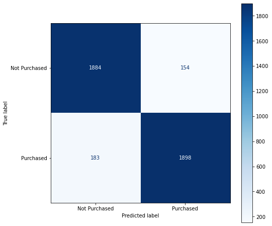

```python
fig, ax = plt.subplots(figsize=(8, 8))
plot_confusion_matrix(model_dt, X_test, Y_test, display_labels=['Not Purchased',
 'Purchased',], cmap=plt.cm.Blues,ax=ax);
```

**• Random Forest**

```python
from sklearn.ensemble import RandomForestClassifier

max_depth=[2, 8, 16]
n_estimators = [64, 128, 256]
param_grid = dict(max_depth=max_depth, n_estimators=n_estimators)


rf_grid = GridSearchCV(RandomForestClassifier(n_estimators=n_estimators, max_depth=max_depth),
                                  param_grid=param_grid,
                                  cv=5)
rf_grid.fit(X_train,Y_train)

print('Best Parameters : {}'.format(rf_grid.best_params_))
print('Best Accuracy Through Grid Search : {:.3f}\n'.format(rf_grid.best_score_))
```

```
Best Parameters : {'max_depth': 16, 'n_estimators': 256}
Best Accuracy Through Grid Search : 0.935
```

```python
model_rf = rf_grid.best_estimator_
```

```python
test_score_rf = model_rf.score(X_test,Y_test)
test_score_rf
```

```
0.9354212187424132
```

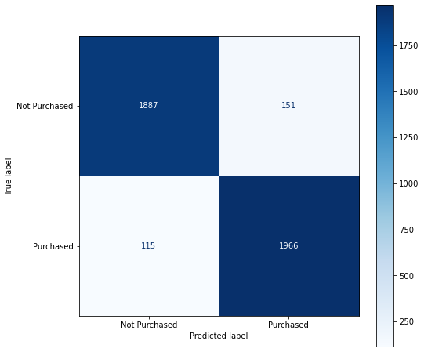

```python
fig, ax = plt.subplots(figsize=(8, 8))
plot_confusion_matrix(model_rf, X_test, Y_test, display_labels=['Not Purchased',
 'Purchased',], cmap=plt.cm.Blues,ax=ax);
```

**• XGBoost**

```python
from xgboost import XGBClassifier

estimator = XGBClassifier(
    objective= 'binary:logistic', # “binary:logistic” function because we train a classifier which handles only two classes.
    nthread=4,
    seed=42
)
parameters = {
    'max_depth': range (2, 10, 1),
    'n_estimators': range(60, 220, 40),
    'learning_rate': [0.1, 0.01, 0.05]
}

xgb_grid = GridSearchCV(estimator=estimator,
                        param_grid=parameters,
                        scoring = 'roc_auc',
                        n_jobs = 10,
                        cv = 10,
                        verbose=True)
xgb_grid.fit(X_train,Y_train)

print('Best Parameters : {}'.format(xgb_grid.best_params_))
print('Best Accuracy Through Grid Search : {:.3f}\n'.format(xgb_grid.best_score_))
```

```
Fitting 10 folds for each of 96 candidates, totalling 960 fits
Best Parameters : {'learning_rate': 0.1, 'max_depth': 8, 'n_estimators': 180}
Best Accuracy Through Grid Search : 0.987
```

```python
model_xgb = xgb_grid.best_estimator_
```

```python
test_score_xgb = model_xgb.score(X_test,Y_test)
test_score_xgb
```

```
0.9414906530711338
```

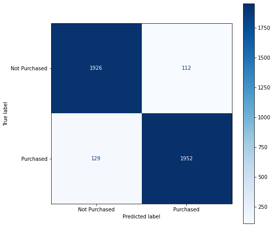

```python
from sklearn.metrics import plot_confusion_matrix
fig, ax = plt.subplots(figsize=(8, 8))
plot_confusion_matrix(model_xgb, X_test, Y_test, display_labels=['Not Purchased',
 'Purchased',], cmap=plt.cm.Blues,ax=ax);
```

**• SVC (Support Vector Classifier)**

```python
from sklearn.model_selection import GridSearchCV
from sklearn.svm import SVC

# defining parameter range
param_grid = {'C': [0.1, 1, 10, 100, 1000],
              'gamma': [1, 0.1, 0.01, 0.001, 0.0001],
              'kernel': ['rbf']}

svc_grid = GridSearchCV(SVC(), param_grid, refit = True, verbose = 3)

# fitting the model for grid search
svc_grid.fit(X_train, Y_train)
```

```
Fitting 5 folds for each of 25 candidates, totalling 125 fits
[CV 1/5] END ........C=0.1, gamma=1, kernel=rbf;, score=0.832 total time=   4.5s
[CV 2/5] END ........C=0.1, gamma=1, kernel=rbf;, score=0.825 total time=   4.4s
[CV 3/5] END ........C=0.1, gamma=1, kernel=rbf;, score=0.833 total time=   4.4s
[CV 4/5] END ........C=0.1, gamma=1, kernel=rbf;, score=0.832 total time=   4.5s
[CV 5/5] END ........C=0.1, gamma=1, kernel=rbf;, score=0.832 total time=   5.8s
[CV 1/5] END ......C=0.1, gamma=0.1, kernel=rbf;, score=0.733 total time=   6.9s
[CV 2/5] END ......C=0.1, gamma=0.1, kernel=rbf;, score=0.724 total time=   6.6s
[CV 3/5] END ......C=0.1, gamma=0.1, kernel=rbf;, score=0.744 total time=   6.6s
[CV 4/5] END ......C=0.1, gamma=0.1, kernel=rbf;, score=0.736 total time=   6.4s
[CV 5/5] END ......C=0.1, gamma=0.1, kernel=rbf;, score=0.740 total time=   9.5s
[CV 1/5] END .....C=0.1, gamma=0.01, kernel=rbf;, score=0.665 total time=   7.4s
[CV 2/5] END .....C=0.1, gamma=0.01, kernel=rbf;, score=0.669 total time=   7.4s
[CV 3/5] END .....C=0.1, gamma=0.01, kernel=rbf;, score=0.680 total time=   7.4s
[CV 4/5] END .....C=0.1, gamma=0.01, kernel=rbf;, score=0.677 total time=   7.7s
[CV 5/5] END .....C=0.1, gamma=0.01, kernel=rbf;, score=0.672 total time=   7.4s
[CV 1/5] END ....C=0.1, gamma=0.001, kernel=rbf;, score=0.501 total time=   7.8s
[CV 2/5] END ....C=0.1, gamma=0.001, kernel=rbf;, score=0.501 total time=   7.8s
[CV 3/5] END ....C=0.1, gamma=0.001, kernel=rbf;, score=0.501 total time=   7.8s
[CV 4/5] END ....C=0.1, gamma=0.001, kernel=rbf;, score=0.501 total time=   7.8s
[CV 5/5] END ....C=0.1, gamma=0.001, kernel=rbf;, score=0.501 total time=   7.8s
[CV 1/5] END ...C=0.1, gamma=0.0001, kernel=rbf;, score=0.501 total time=   7.6s
[CV 2/5] END ...C=0.1, gamma=0.0001, kernel=rbf;, score=0.501 total time=   7.8s
[CV 3/5] END ...C=0.1, gamma=0.0001, kernel=rbf;, score=0.501 total time=   7.7s
[CV 4/5] END ...C=0.1, gamma=0.0001, kernel=rbf;, score=0.501 total time=   8.0s
[CV 5/5] END ...C=0.1, gamma=0.0001, kernel=rbf;, score=0.501 total time=   7.8s
[CV 1/5] END ..........C=1, gamma=1, kernel=rbf;, score=0.866 total time=   3.5s
[CV 2/5] END ..........C=1, gamma=1, kernel=rbf;, score=0.856 total time=   3.4s
[CV 3/5] END ..........C=1, gamma=1, kernel=rbf;, score=0.866 total time=   3.6s
[CV 4/5] END ..........C=1, gamma=1, kernel=rbf;, score=0.870 total time=   3.6s
[CV 5/5] END ..........C=1, gamma=1, kernel=rbf;, score=0.871 total time=   3.6s
[CV 1/5] END ........C=1, gamma=0.1, kernel=rbf;, score=0.842 total time=   6.3s
[CV 2/5] END ........C=1, gamma=0.1, kernel=rbf;, score=0.828 total time=   4.5s
[CV 3/5] END ........C=1, gamma=0.1, kernel=rbf;, score=0.845 total time=   4.8s
[CV 4/5] END ........C=1, gamma=0.1, kernel=rbf;, score=0.840 total time=   4.5s
[CV 5/5] END ........C=1, gamma=0.1, kernel=rbf;, score=0.845 total time=   4.7s
[CV 1/5] END .......C=1, gamma=0.01, kernel=rbf;, score=0.723 total time=   6.1s
[CV 2/5] END .......C=1, gamma=0.01, kernel=rbf;, score=0.715 total time=   6.0s
[CV 3/5] END .......C=1, gamma=0.01, kernel=rbf;, score=0.731 total time=   6.1s
[CV 4/5] END .......C=1, gamma=0.01, kernel=rbf;, score=0.725 total time=   6.0s
```

[output cut: 71 more lines]

```
[CV 1/5] END ....C=1000, gamma=0.01, kernel=rbf;, score=0.875 total time=   3.9s
[CV 2/5] END ....C=1000, gamma=0.01, kernel=rbf;, score=0.868 total time=   3.7s
[CV 3/5] END ....C=1000, gamma=0.01, kernel=rbf;, score=0.873 total time=   3.9s
[CV 4/5] END ....C=1000, gamma=0.01, kernel=rbf;, score=0.869 total time=   4.0s
[CV 5/5] END ....C=1000, gamma=0.01, kernel=rbf;, score=0.877 total time=   4.0s
[CV 1/5] END ...C=1000, gamma=0.001, kernel=rbf;, score=0.832 total time=   4.3s
[CV 2/5] END ...C=1000, gamma=0.001, kernel=rbf;, score=0.825 total time=   4.1s
[CV 3/5] END ...C=1000, gamma=0.001, kernel=rbf;, score=0.827 total time=   4.3s
[CV 4/5] END ...C=1000, gamma=0.001, kernel=rbf;, score=0.831 total time=   4.4s
[CV 5/5] END ...C=1000, gamma=0.001, kernel=rbf;, score=0.831 total time=   4.4s
[CV 1/5] END ..C=1000, gamma=0.0001, kernel=rbf;, score=0.798 total time=   5.1s
[CV 2/5] END ..C=1000, gamma=0.0001, kernel=rbf;, score=0.787 total time=   4.8s
[CV 3/5] END ..C=1000, gamma=0.0001, kernel=rbf;, score=0.800 total time=   5.0s
[CV 4/5] END ..C=1000, gamma=0.0001, kernel=rbf;, score=0.803 total time=   5.0s
[CV 5/5] END ..C=1000, gamma=0.0001, kernel=rbf;, score=0.807 total time=   5.0s
```

```
GridSearchCV(estimator=SVC(),
             param_grid={'C': [0.1, 1, 10, 100, 1000],
                         'gamma': [1, 0.1, 0.01, 0.001, 0.0001],
                         'kernel': ['rbf']},
             verbose=3)
```

```python
print('Best Parameters : {}'.format(svc_grid.best_params_))
print('Best Accuracy Through Grid Search : {:.3f}\n'.format(svc_grid.best_score_))
```

```
Best Parameters : {'C': 1000, 'gamma': 1, 'kernel': 'rbf'}
Best Accuracy Through Grid Search : 0.897
```

```python
model_svc = svc_grid.best_estimator_
```

```python
test_score_svc = model_svc.score(X_test,Y_test)
test_score_svc
```

```
0.891964068948774
```

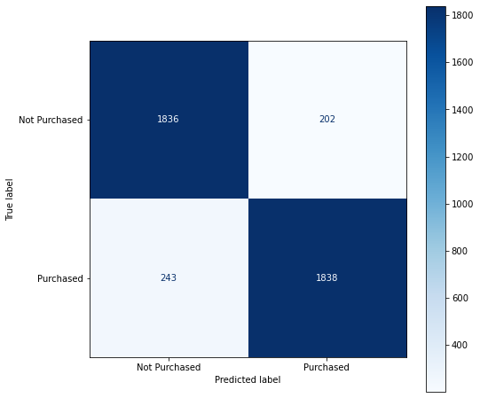

```python
fig, ax = plt.subplots(figsize=(8, 8))
plot_confusion_matrix(model_svc, X_test, Y_test, display_labels=['Not Purchased',
 'Purchased',], cmap=plt.cm.Blues,ax=ax);
```

**• Stochastic gradient descent**

```python
from sklearn.linear_model import SGDClassifier
param_grid = {
    "loss": ["hinge","log","squared_hinge","perceptron"],
    "penalty": ["elasticnet", "l1", "l2"],
    "learning_rate": ['constant', 'optimal', 'invscaling', 'adaptive'],
    "max_iter": [150,300,450],
    "alpha": [0.0001, 0.001,0.05,0.01],
    "eta0": [5,10]
    }
sgd = GridSearchCV(SGDClassifier(),param_grid, cv=5, n_jobs=-1,scoring='f1', verbose=True)

sgd.fit(X_train,Y_train)

print('Best Parameters : {}'.format(sgd.best_params_))
print('Best Accuracy Through Grid Search : {:.3f}\n'.format(sgd.best_score_))
```

[output not shown]

```python
model_sgd = sgd.best_estimator_
```

```python
test_score_sgd = model_sgd.score(X_test,Y_test)
test_score_sgd
```

```
0.7378004369992717
```

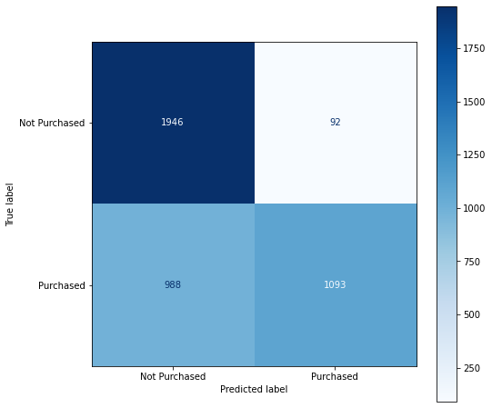

```python
from sklearn.metrics import plot_confusion_matrix
fig, ax = plt.subplots(figsize=(8, 8))
plot_confusion_matrix(model_sgd, X_test, Y_test, display_labels=['Not Purchased',
 'Purchased',], cmap=plt.cm.Blues,ax=ax);
```

**• Gradient boosting score**

```python
from sklearn.ensemble import GradientBoostingClassifier
parameters = [{
    "loss":["deviance"],
    "learning_rate": [0.2,0.3,0.4],
    "min_samples_split": [0.01,0.1, 0.5],
    "min_samples_leaf": [0.0001,0.001, 0.01],
    "max_depth":[8,10,15],
    "max_features":["log2","sqrt"],
    "criterion": ["friedman_mse",  "mae"],
    "subsample":[0.7,0.8,0.9],
    "n_estimators":[10,20,30]
    }]
gbm = GridSearchCV(GradientBoostingClassifier(), parameters, cv=5, n_jobs=-1,scoring='f1', verbose=True)
gbm.fit(X_train,Y_train)

print('Best Parameters : {}'.format(gbm.best_params_))
print('Best Accuracy Through Grid Search : {:.3f}\n'.format(gbm.best_score_))
```

```
Fitting 5 folds for each of 2916 candidates, totalling 14580 fits
Best Parameters : {'criterion': 'friedman_mse', 'learning_rate': 0.2, 'loss': 'deviance', 'max_depth': 15, 'max_features': 'sqrt', 'min_samples_leaf': 0.0001, 'min_samples_split': 0.01, 'n_estimators': 30, 'subsample': 0.9}
Best Accuracy Through Grid Search : 0.939
```

```python
model_gbm = sgd.best_estimator_
```

```python
test_score_gbm = model_gbm.score(X_test,Y_test)
test_score_gbm
```

```
0.7378004369992717
```

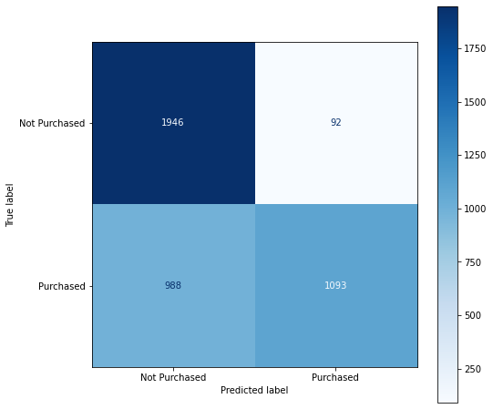

```python
from sklearn.metrics import plot_confusion_matrix
fig, ax = plt.subplots(figsize=(8, 8))
plot_confusion_matrix(model_gbm, X_test, Y_test, display_labels=['Not Purchased',
 'Purchased',], cmap=plt.cm.Blues,ax=ax);
```

**• Model Selection**

Scores Ranking

```python
data = {'Model': ['KNN', 'Naive Bayes Classifier', 'Decision Tree', 'Random Forest','XGBoost','SVC','Stochastic Gradient Descent','Gradient Boosting Score'],
        'Score': [test_score_knn, test_score_nb, test_score_dt, test_score_rf,test_score_xgb, test_score_svc,test_score_sgd,test_score_gbm]}

df_model_score = pd.DataFrame(data)
df_model_score.sort_values(by='Score', ascending=False).reset_index(drop=True)
```

[output not shown]

ROC Curves

```python
from sklearn.metrics import (precision_recall_curve, auc, roc_curve, recall_score,
                             classification_report, f1_score, average_precision_score, precision_recall_fscore_support)
```

```python
#KNN
y_pred_prob_KNN = model_knn.predict_proba(X_test)[:,1]
fpr_KNN, tpr_KNN, thresholds_KNN = roc_curve(Y_test, y_pred_prob_KNN)
roc_auc_KNN = auc(fpr_KNN, tpr_KNN)
precision_KNN, recall_KNN, th_KNN = precision_recall_curve(Y_test, y_pred_prob_KNN)

#Naive Bayes Classifier
y_pred_prob_NB = model_nb.predict_proba(X_test)[:,1]
fpr_NB, tpr_NB, thresholds_NB = roc_curve(Y_test, y_pred_prob_NB)
roc_auc_NB = auc(fpr_NB, tpr_NB)
precision_NB, recall_NB, th_NB = precision_recall_curve(Y_test, y_pred_prob_NB)

#Decision Tree
y_pred_prob_Tree = model_dt.predict_proba(X_test)[:,1]
fpr_Tree, tpr_Tree, thresholds_Tree = roc_curve(Y_test, y_pred_prob_Tree)
roc_auc_Tree = auc(fpr_Tree, tpr_Tree)
precision_Tree, recall_Tree, th_Tree = precision_recall_curve(Y_test, y_pred_prob_Tree)

# Random forest
y_pred_prob_rf = model_rf.predict_proba(X_test)[:,1]
fpr_rf, tpr_rf, thresholds_rf = roc_curve(Y_test, y_pred_prob_rf)
roc_auc_rf = auc(fpr_rf, tpr_rf)
precision_rf, recall_rf, th_rf = precision_recall_curve(Y_test, y_pred_prob_rf)

# XGB Boost
y_pred_prob_xgb = model_xgb.predict_proba(X_test)[:,1]
fpr_xgb, tpr_xgb, thresholds_xgb = roc_curve(Y_test, y_pred_prob_xgb)
roc_auc_xgb = auc(fpr_rf, tpr_rf)
precision_xgb, recall_xgb, th_xgb = precision_recall_curve(Y_test, y_pred_prob_xgb)
```

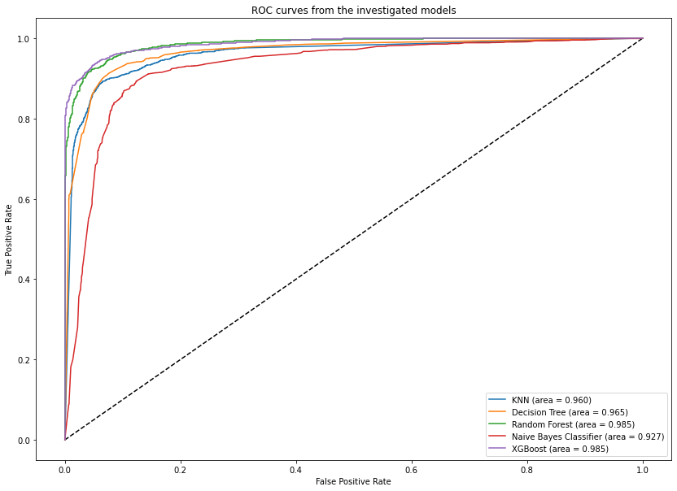

```python
# Plot ROC curve
fig, ax = plt.subplots(figsize=(14, 10))
plt.plot([0, 1], [0, 1], 'k--')
plt.plot(fpr_KNN, tpr_KNN, label='KNN (area = %0.3f)' % roc_auc_KNN)
plt.plot(fpr_Tree, tpr_Tree, label='Decision Tree (area = %0.3f)' % roc_auc_Tree)
plt.plot(fpr_rf, tpr_rf, label='Random Forest (area = %0.3f)' % roc_auc_rf)
plt.plot(fpr_NB, tpr_NB, label='Naive Bayes Classifier (area = %0.3f)' % roc_auc_NB)
plt.plot(fpr_xgb, tpr_xgb, label='XGBoost (area = %0.3f)' % roc_auc_xgb)
plt.xlabel('False Positive Rate')
plt.ylabel('True Positive Rate')
plt.title('ROC curves from the investigated models')
plt.legend(loc='best')
plt.show()
```

As we can see, the models that are standing out are respectively XGBoost, Random Forest, and Decision Tree. Among these three, based on their scores on the test set, the best classifier is XGBoost. Thus, it's the one that we are going to export for our `API`.

## 6. API

In order to make our API we need to export our best model (ie `XGB`). This will allow us to process our new data and make a prediction.

```python
import pickle

pickle.dump(model_xgb,open('model_xgb.pkl','wb'))
```

Here are the differents steps that needs to be followed in order to implement our API :

1. Download and extract the zip file related to our [Github repository](https://github.com/nilanyK/ESILV---Python-For-Data-Analysis---Project-2023/blob/main/README.md).
2. Open the folder titled "API" on Visual Studio Code or another IDE of your choice.
3. Open a terminal and execute the "run.py" file by entering the following command :

   ```
   python run.py
   ```

4. The output will display the link on which the server is running (for me it was http://127.0.0.1:5000, it might be different for you)
5. Copy-paste the link on your browser.
6. Fill in the form with your input data and submit it by clicking on the `Predict` button.
7. After submitting the form, scroll down as the result of the prediction should be displayed (ie if either the customer will or not purchase).